# ΜΙΣΤΑ002: Paired t-test

## Paired t-test

Paired t-test can be used if we have two samples that are related to each other and one quantitative variable of interest. Examples of paired study designs are:

- measurements collected before and after an intervention in an experimental study
- twins, husbands and wives, brothers and sisters
- matched cases and controls
- a cross-over trial in which each patient has two measurements on the variable, one while taking active treatment and one while taking placebo

A paired t-test is used to assess whether the mean of the differences between the two related measurements, x and y, is significantly different from zero.

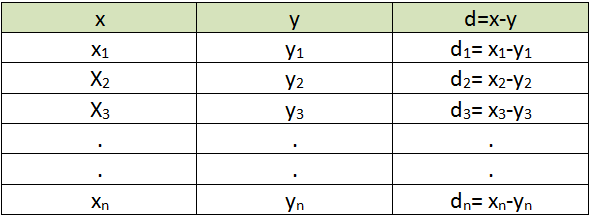

**Assumptions**

In the population of interest, the differences between the pairs of measurements are normally distributed.

**Notation**

**Steps for conducting the test**

**Step 1. Define the null and alternative hypotheses under study**

**H<sub>0</sub>**: the mean difference in the population equals zero (μ<sub>d</sub>=0) .

**H<sub>1</sub>**: the mean difference in the population does not equal zero (μ<sub>d</sub>≠0).

**Step 2. Calculate the value of the test statistic specific to H<sub>0</sub>**

Under the null hypothesis, the t statistic follows the t-distribution with n-1 degrees of freedom (d.f.).

**Step 3. Calculate the p value from the t-distribution**

The corresponding p-value for the t statistic can be calculated as the cumulative probability Pr(T>|t|) for a variable T that follows a t distribution with n-1 degrees of freedom. H<sub>0</sub> is rejected if the p-value is less than the significance level alpha (e.g. 0.05).

An old fashioned way for testing H<sub>0</sub> would be to compare the calculated t statistic with the corresponding critical value at level alpha of the t distribution. This is rarely used in the computers era, if ever.

In practice, after calculating the t statistic, one may resort to online calculators of the t-distribution (e.g. http://stattrek.com/online-calculator/t-distribution.aspx) in order to get the cumulative probability that T<t. Then, the p-value is 2*(1-Pr(T<t)). Statistical software (e.g. R, SPSS) automatically provide the p-value.

**Step 4. Calculate the Confidence Interval (CI)**

Note that, if the mean difference is significantly different from zero, the (1-a)%CI of the mean difference will not include the zero.

**Step 5. Interpretation**

Interpretation of the results.

Worked Example

[figure not shown]

Systolic blood pressure levels were measured in 16 middle-aged men before and after a standard exercise. The mean difference (after-before) in systolic blood pressure following exercise was 6.6mmHg (risen) and the standard deviation of the differences was 6.0mmHg. Supposed that the assumption of Normality of the differences is satisfied, perform a two-tailed paired t-test to investigate if the mean difference is significant (a=0.05) (example from Altman, 2000).

**Step 1. Define the null and alternative hypotheses under study**

**H<sub>0</sub>**: the true mean difference of the blood pressure following exercise equals zero (μ<sub>d</sub>=0) .

**H<sub>1</sub>**: the true mean difference of the blood pressure following exercise does not equal zero (μ<sub>d</sub>≠0).

**Step 2. Calculate the value of the test statistic specific to H<sub>0</sub>**

The t statistic follows the t-distribution with 15 degrees of freedom.

**Step 3. **Calculate the p value from the t-distribution****

From an online calculator we get Pr(T<4.4)=0.9997. Then, the p-value is 2*(1-0.9997)=0.0006 < 0.05.

**Step 4. Calculate the Confidence Interval (CI)**

**Therefore, the 95% confidence interval for the true mean difference ranges from** 3.4**mmHg to** 9.8mmHg . Note that the zero is not included in the 95%CI of the mean difference.  
Step 5. Interpretation  
The mean difference (after-before) in systolic blood pressure following exercise was 6.6mmHg (sd=6.0mmHg) which was a significant difference (p<0.001).

Last modified: Wednesday, 13 February 2019, 7:59 PM